# Smith’s Examples

Simon Brewer

5/19/2023

Examples taken from ‘Evaluating Counterfactual Explanations Using Pearl’s Counterfactual Method’. Bevan I Smith (arxiv.org)

## Libraries and whatnot

```r
library(tidyverse)
# library(broom)
library(patchwork)
library(scales)
library(dagitty)
library(ggdag)
library(latex2exp)  # Easily convert LaTeX into arcane plotmath expressions
library(ggtext)     # Use markdown in ggplot labels

# Create a cleaner serifed theme to use throughout
theme_do_calc <- function() {
  theme_dag(base_family = "Times New Roman") +
    theme(plot.title = element_text(size = rel(1.5)),
          plot.subtitle = element_markdown())
}

# Make all geom_dag_text() layers use these settings automatically
update_geom_defaults(ggdag:::GeomDagText, list(family = "Times New Roman",
                                               fontface = "bold",
                                               color = "black"))
```

## Causal structures

In all the following we are interested in the causal effect of an intervention or endogenous factors (`X`) on an outcome (`Y`), given confounders (`Z`) and exogenous or unknown factors (`U`). The exogenous factors refer to all external features that we cannot account for

### Chain (mediator)

This represents a sequential path from intervention to outcome via a confounder (`X` → `Z` → `Y`).

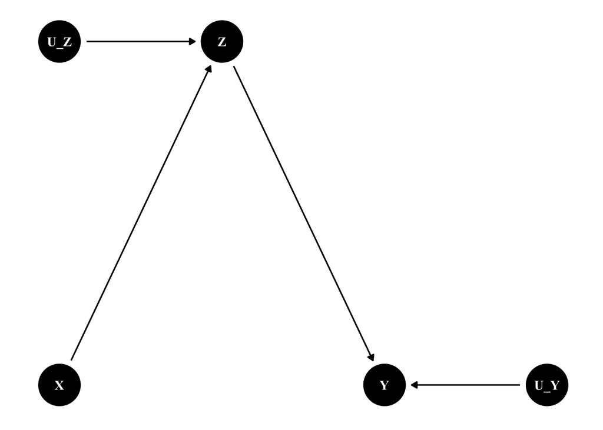

```r
chain_dag <- dagify(Z ~ X + U_Z,
                    Y ~ Z + U_Y,
                    coords = list(x = c(X = 1, U_Z = 1, Z = 2, Y = 3, U_Y = 4),
                                  y = c(X = 1, U_Z = 2, Z = 2, Y = 1, U_Y = 1)),
                    exposure = "X",
                    outcome = "Y",
                    latent = c("U_Y", "U_Z"))

ggdag(chain_dag) +
  theme_dag()
```

Equations:

$$Z = f(X, U_Z)$$
$$Y = f(Z, U_Y)$$

Independence: `X` and `Y` are independent (conditioned on `Z`)

```r
impliedConditionalIndependencies(chain_dag)
```

```
## X _||_ Y | Z
```

Adjustment set: shows what adjustment is necessary to obtain the causal link between input and outcome. Important note here - the adjustment set says to ignore `z` in this case. If we, this is a ‘overcontrol’ - we’ll remove or bias the *total* causal link between `x` and `y`

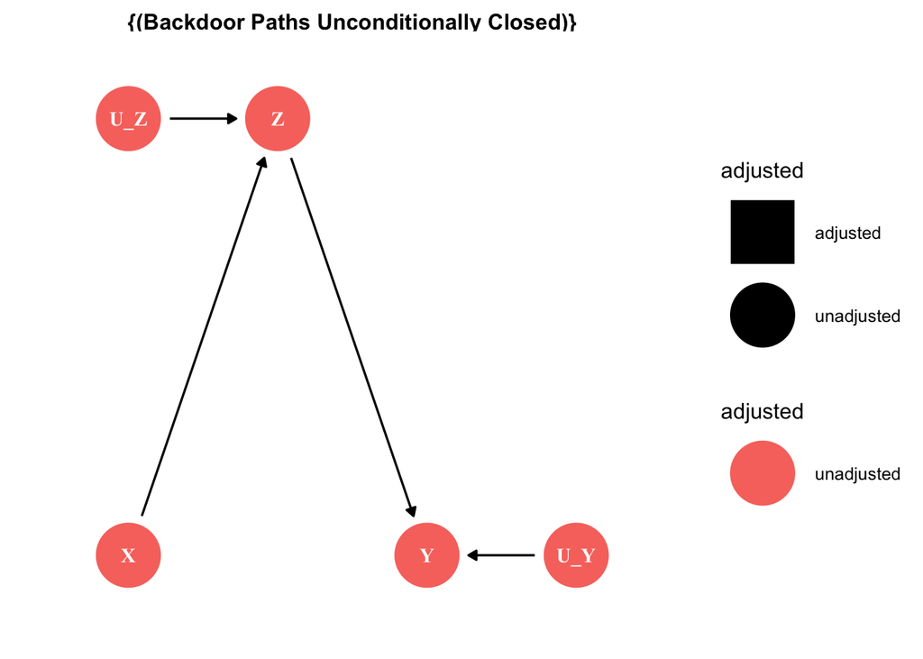

```r
ggdag_adjustment_set(chain_dag) +
  theme_dag()
```

Separation:

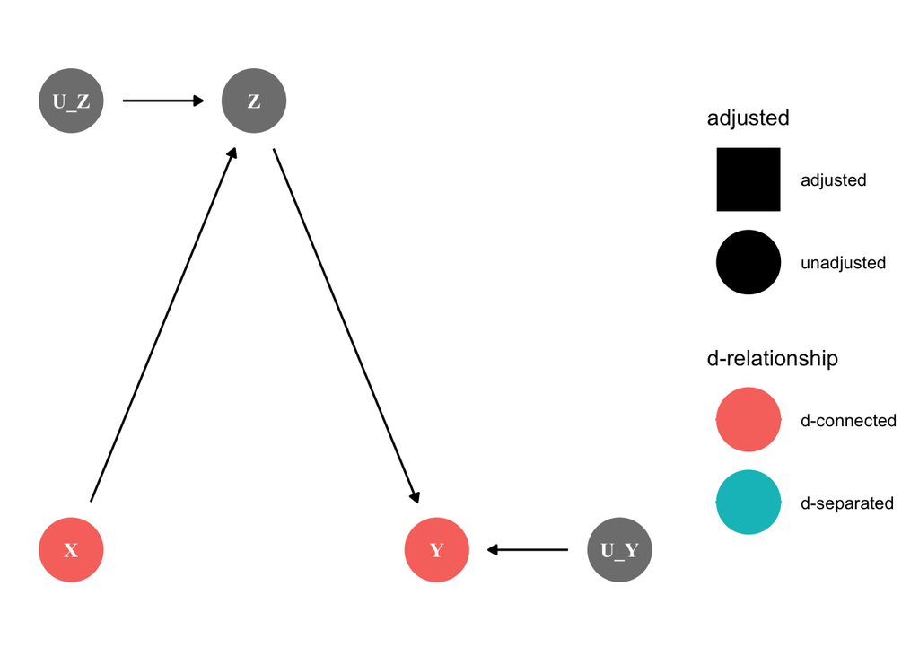

```r
ggdag_dseparated(chain_dag) +
  theme_dag()
```

If we control for `z` this artificially separates the exposure and outcome:

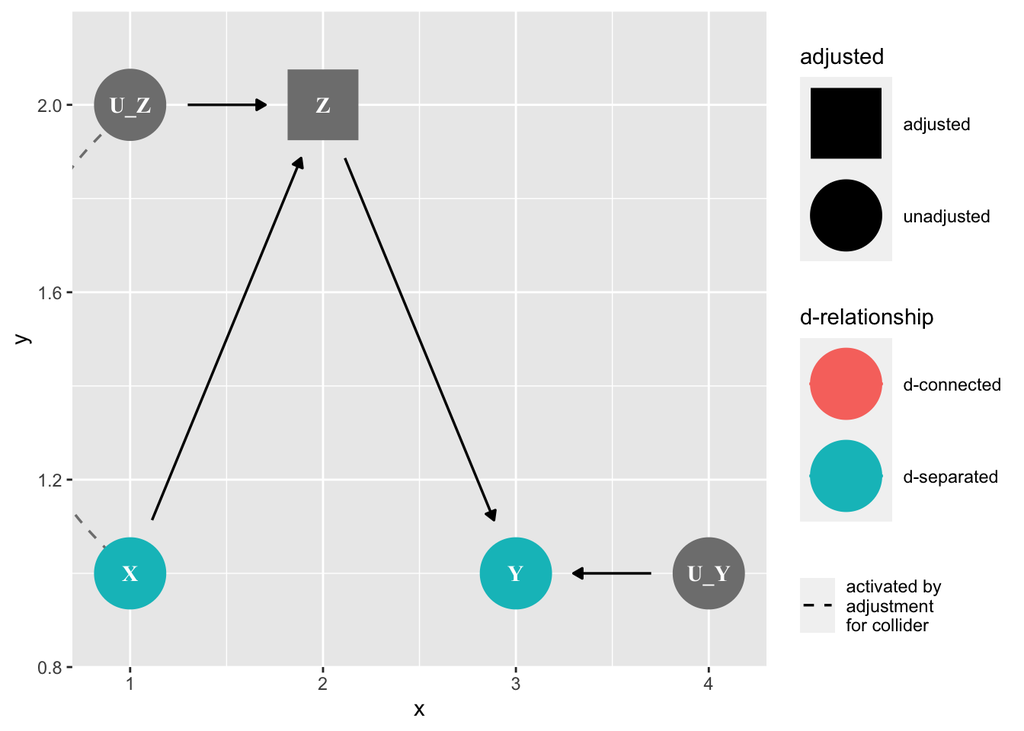

```r
ggdag_dseparated(chain_dag, controlling_for = "Z")
```

## Fork (common cause)

This represents a spurious correlations (i.e. when there is a common cause that affects `X` and `Y`, then they will be correlated without existing causality).

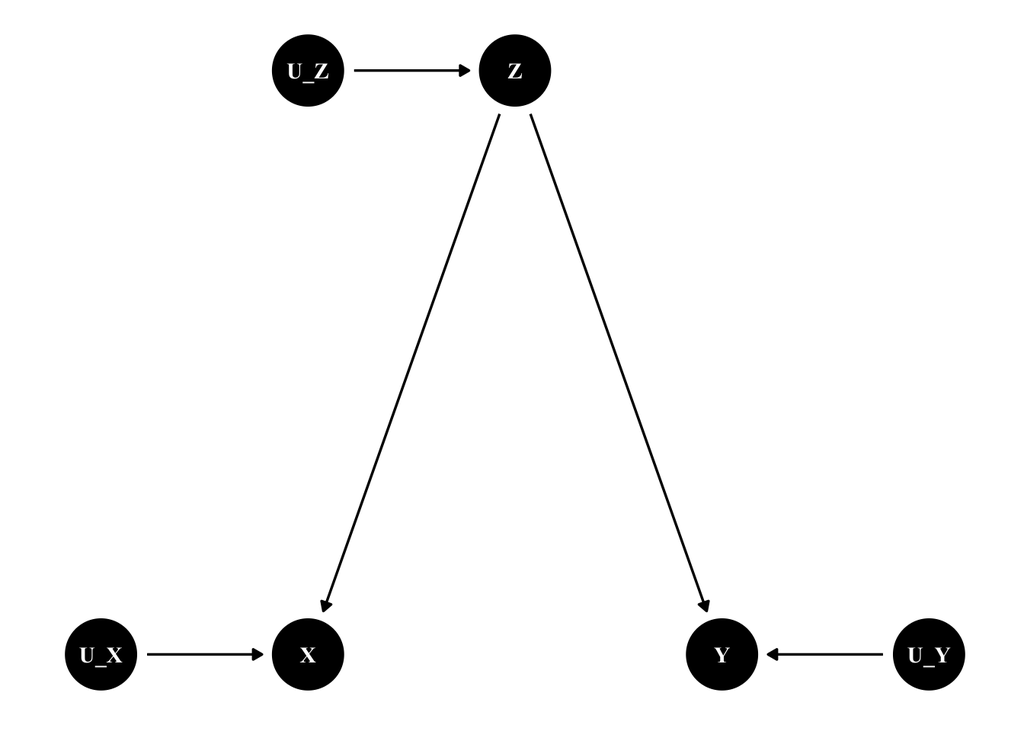

```r
fork_dag <- dagify(X ~ Z + U_X,
                   Z ~ U_Z,
                    Y ~ Z + U_Y,
                    coords = list(x = c(U_X = 0, X = 1, U_Z = 1, Z = 2, Y = 3, U_Y = 4),
                                  y = c(U_X = 1, X = 1, U_Z = 2, Z = 2, Y = 1, U_Y = 1)),
                    exposure = "X",
                    outcome = "Y",
                    latent = c("U_X", "U_Y", "U_Z"))

ggdag(fork_dag) +
  theme_dag()
```

Equations:

$$X = f(Z,U_X)$$
$$Z = f(U_Z)$$
$$Y = f(Z, U_Y)$$

Independence: `X` and `Y` are independent (conditioned on `Z`)

```r
impliedConditionalIndependencies(fork_dag)
```

```
## X _||_ Y | Z
```

Adjustment set: shows what adjustment is necessary to obtain the causal link between input and outcome

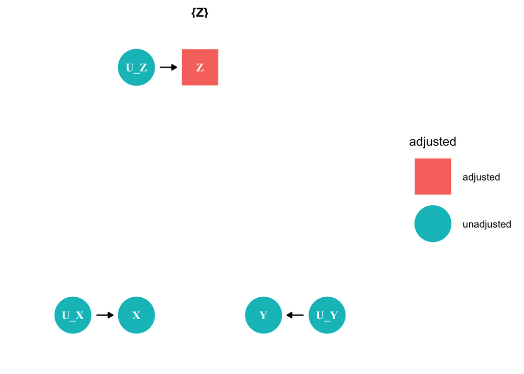

```r
ggdag_adjustment_set(fork_dag) +
  theme_dag()
```

Separation:

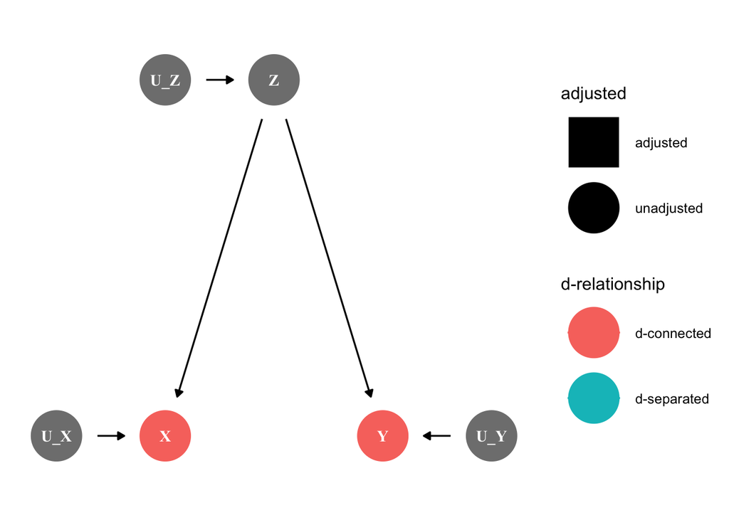

```r
ggdag_dseparated(fork_dag) +
  theme_dag()
```

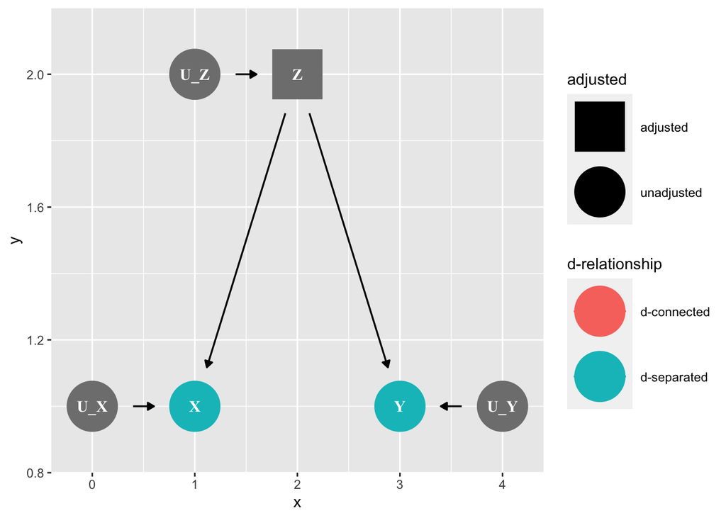

```r
ggdag_dseparated(fork_dag, controlling_for = "Z")
```

## Collider (common effect)

This represents the existence of a variable that is impacted by both the intervention and the outcome (i.e. `X` → `Z` ← `Y`). Controlling for a collider can result in spurious correlation (as it links variations in `X` and `Y`).

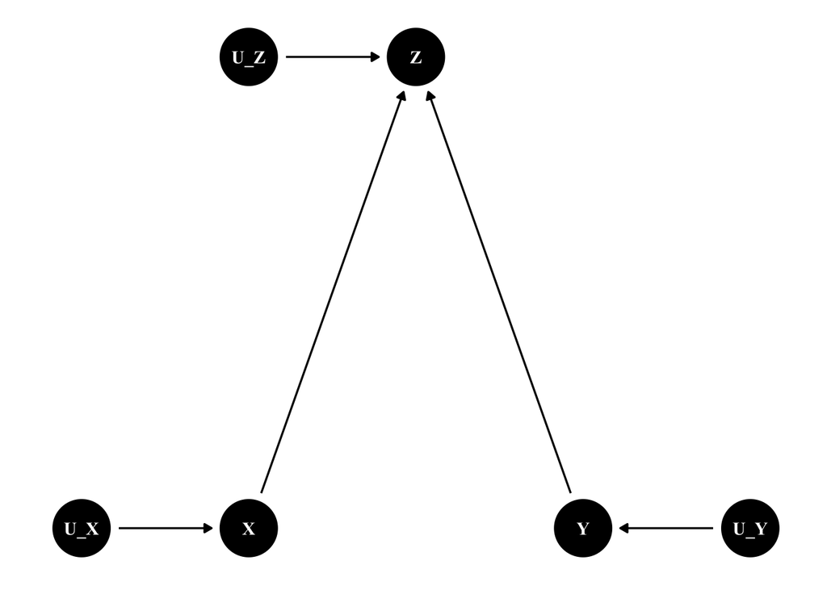

```r
collider_dag <- dagify(X ~ U_X,
                   Z ~ X + Y + U_Z,
                    Y ~ U_Y,
                    coords = list(x = c(U_X = 0, X = 1, U_Z = 1, Z = 2, Y = 3, U_Y = 4),
                                  y = c(U_X = 1, X = 1, U_Z = 2, Z = 2, Y = 1, U_Y = 1)),
                    exposure = "X",
                    outcome = "Y",
                    latent = c("U_X", "U_Y", "U_Z"))

ggdag(collider_dag) +
  theme_dag()
```

Equations:

$$X = f(U_X)$$
$$Z = f(X,Y,U_Z)$$
$$Y = f(U_Y)$$

```r
impliedConditionalIndependencies(collider_dag)
```

```
## X _||_ Y
```

Adjustment set: shows what adjustment is necessary to obtain the causal link between input and outcome

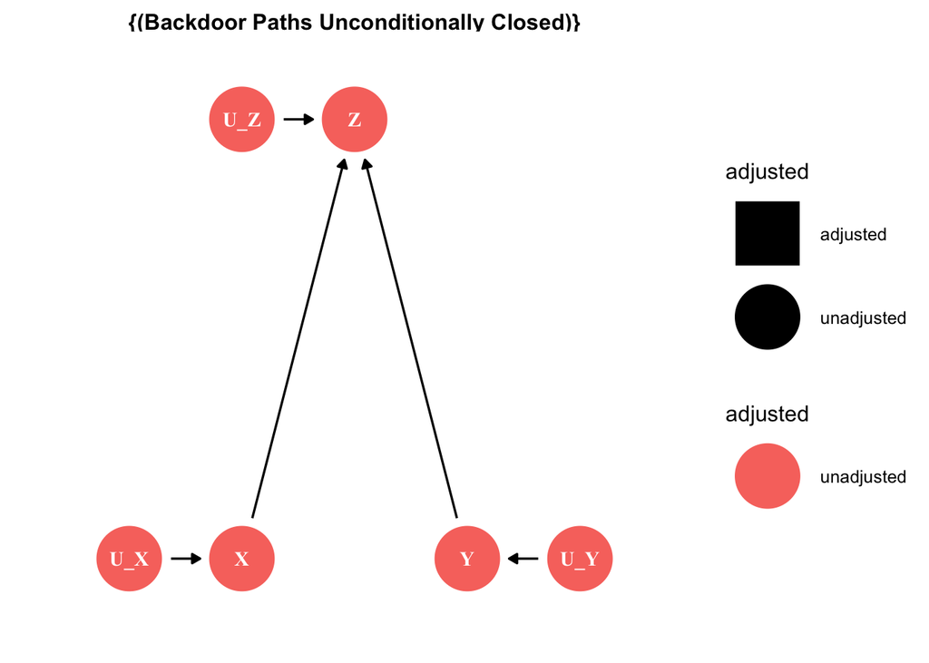

```r
ggdag_adjustment_set(collider_dag) +
  theme_dag()
```

Separation:

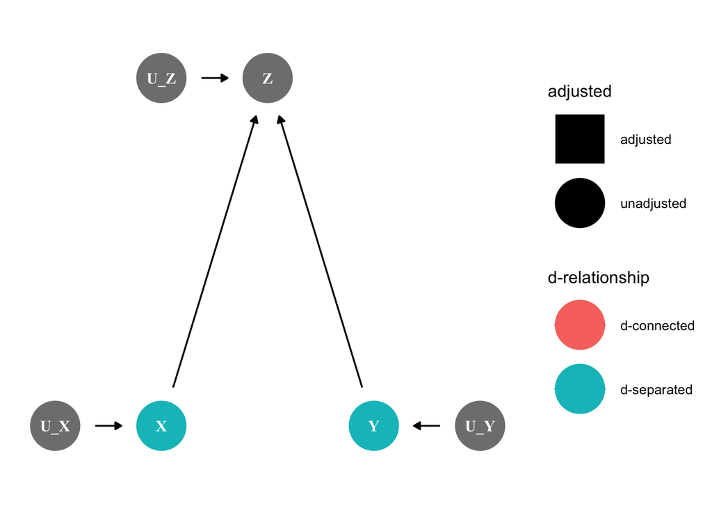

```r
ggdag_dseparated(collider_dag) +
  theme_dag()
```

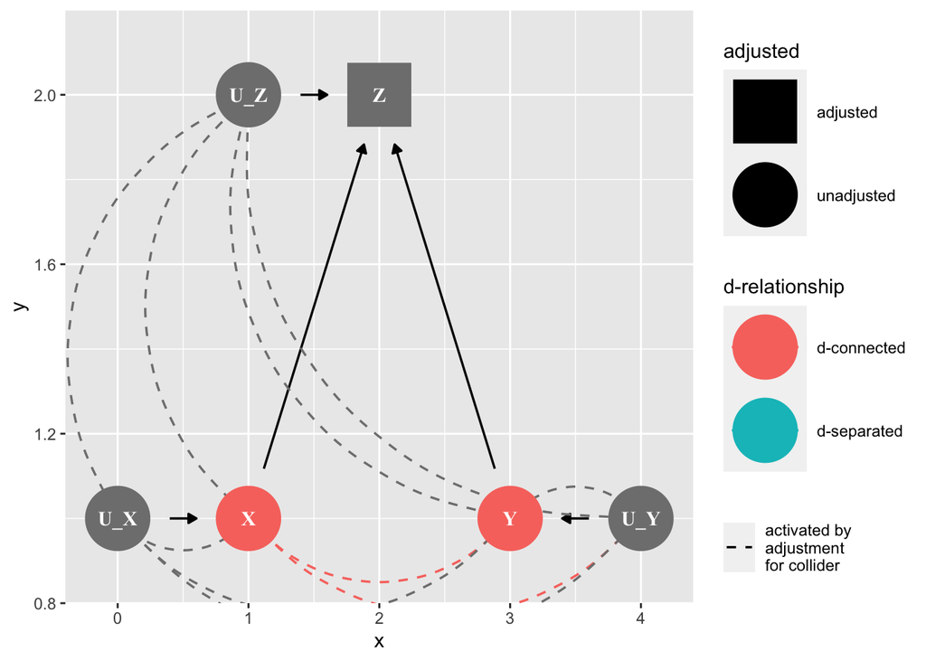

```r
ggdag_dseparated(collider_dag, controlling_for = "Z")
```

## Difference between correlation models and causal models

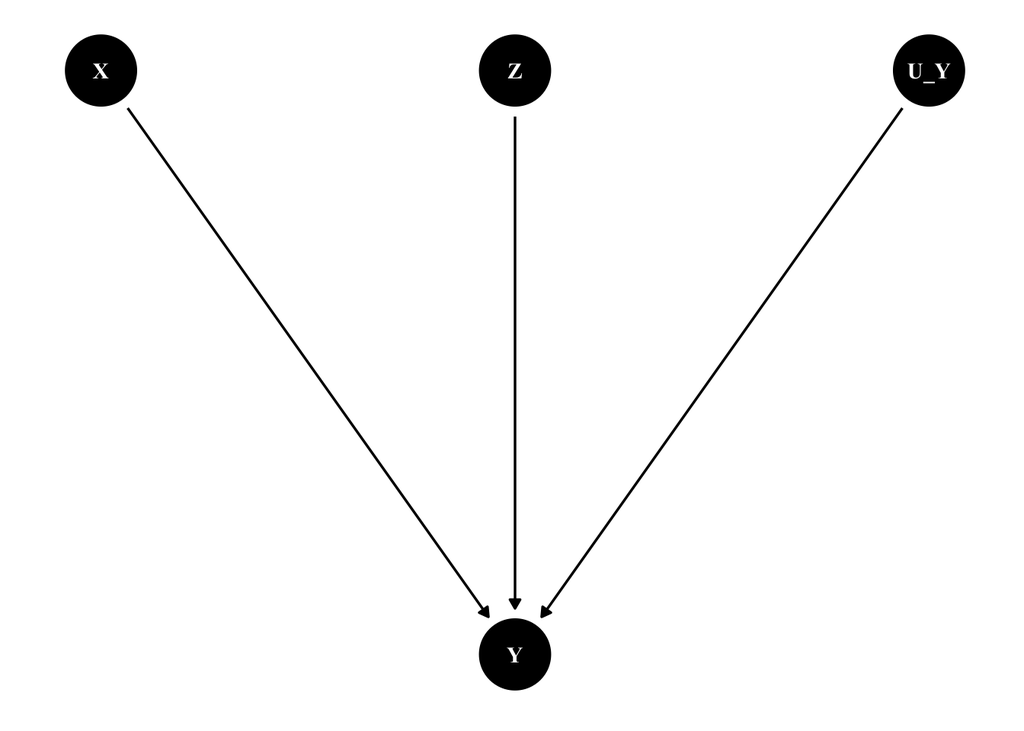

```r
ml_dag <- dagify(Y ~ X + Z + U_Y,
                    coords = list(x = c(X = 1, Z = 2, Y = 2, U_Y = 3),
                                  y = c(X = 2, Z = 2, Y = 1, U_Y = 2)),
                    exposure = "X",
                    outcome = "Y",
                    latent = c("U_Y"))

ggdag(ml_dag) +
  theme_dag()
```

Equations:

$$Y = f(X,Z,U_Y)$$